# Outlier VIF

!! Variables that are correlated with each other don’t have a higher chance of interacting with each other in a model. Interaction means that the effect of one on the outcome will depend on the other. While correlation only means that the 2 variables tend to vary together in a linear fashion. And the latter says nothing about the effect of each on the outcome Y

Backward model: crm_1000 ~ pop18 + docs + beds + poverty + pcincome + region + pop_density

## Read in

```r
crime_df =
  read_csv("cdi.csv") %>%
  mutate(
    region = factor(region),
    pop_density = pop / area,
    crm_1000 = 1000 * crimes / pop
  ) %>%
  dplyr::select(-crimes, -id, -area, -pop) %>%
  dplyr::select(crm_1000, everything()) %>%
  drop_na()
```

## Candidate Models

Models

```r
backward = lm(crm_1000 ~ pop18 + docs + beds +
    poverty + pcincome + region + pop_density, data = crime_df)

doc_totalinc = lm(crm_1000 ~ poverty + hsgrad + beds + docs + region + pop_density + beds * docs + beds * totalinc, data = crime_df)
broom::tidy(doc_totalinc)
```

```
## # A tibble: 12 × 5
##    term               estimate     std.error statistic  p.value
##    <chr>                 <dbl>         <dbl>     <dbl>    <dbl>
##  1 (Intercept)   -13.2         15.3             -0.859 3.91e- 1
##  2 poverty         1.58         0.299            5.27  2.17e- 7
##  3 hsgrad          0.400        0.179            2.24  2.58e- 2
##  4 beds            0.00971      0.00139          6.97  1.22e-11
##  5 docs            0.00298      0.00294          1.01  3.11e- 1
##  6 region2         9.41         2.51             3.75  1.98e- 4
##  7 region3        26.0          2.39            10.9   1.38e-24
##  8 region4        20.1          2.90             6.94  1.47e-11
##  9 pop_density     0.00465      0.000452        10.3   2.54e-22
## 10 totalinc       -0.00106      0.000400        -2.65  8.40e- 3
## 11 beds:docs      -0.00000220   0.000000512     -4.29  2.19e- 5
## 12 beds:totalinc   0.000000254  0.0000000660     3.86  1.33e- 4
```

```r
bed_totalinc = lm(crm_1000 ~ poverty + hsgrad + beds + docs + region + pop_density + beds * docs + docs * totalinc, data = crime_df)
broom::tidy(bed_totalinc)
```

```
## # A tibble: 12 × 5
##    term               estimate     std.error statistic  p.value
##    <chr>                 <dbl>         <dbl>     <dbl>    <dbl>
##  1 (Intercept)   -20.8         15.1              -1.38 1.68e- 1
##  2 poverty         1.62         0.297             5.46 8.02e- 8
##  3 hsgrad          0.474        0.177             2.68 7.58e- 3
##  4 beds            0.0132       0.00186           7.12 4.61e-12
##  5 docs           -0.00531      0.00210          -2.53 1.18e- 2
##  6 region2         9.47         2.51              3.78 1.81e- 4
##  7 region3        26.4          2.39             11.1  3.62e-25
##  8 region4        20.2          2.90              6.98 1.11e-11
##  9 pop_density     0.00468      0.000453         10.3  1.65e-22
## 10 totalinc       -0.000497     0.000294         -1.69 9.21e- 2
## 11 beds:docs      -0.00000130   0.000000279      -4.68 3.94e- 6
## 12 docs:totalinc   0.000000165  0.0000000423      3.90 1.11e- 4
```

```r
summary(backward)
```

```
##
## Call:
## lm(formula = crm_1000 ~ pop18 + docs + beds + poverty + pcincome +
##     region + pop_density, data = crime_df)
##
## Residuals:
##     Min      1Q  Median      3Q     Max
## -58.897 -10.357  -1.298  10.510  68.126
##
## Coefficients:
##               Estimate Std. Error t value Pr(>|t|)
## (Intercept) -2.972e+01  1.002e+01  -2.967 0.003170 **
## pop18        8.167e-01  2.101e-01   3.887 0.000117 ***
## docs        -9.870e-03  1.802e-03  -5.477 7.35e-08 ***
## beds         9.035e-03  1.385e-03   6.526 1.90e-10 ***
## poverty      1.869e+00  2.614e-01   7.150 3.75e-12 ***
## pcincome     1.296e-03  3.130e-04   4.139 4.20e-05 ***
## region2      1.096e+01  2.501e+00   4.381 1.48e-05 ***
## region3      2.656e+01  2.435e+00  10.905  < 2e-16 ***
## region4      2.315e+01  2.810e+00   8.240 2.11e-15 ***
## pop_density  4.484e-03  4.525e-04   9.911  < 2e-16 ***
## ---
## Signif. codes:  0 '***' 0.001 '**' 0.01 '*' 0.05 '.' 0.1 ' ' 1
##
## Residual standard error: 17.63 on 430 degrees of freedom
## Multiple R-squared:  0.5921, Adjusted R-squared:  0.5836
## F-statistic: 69.36 on 9 and 430 DF,  p-value: < 2.2e-16
```

## Outliers and Leverage

Filter out influential observations

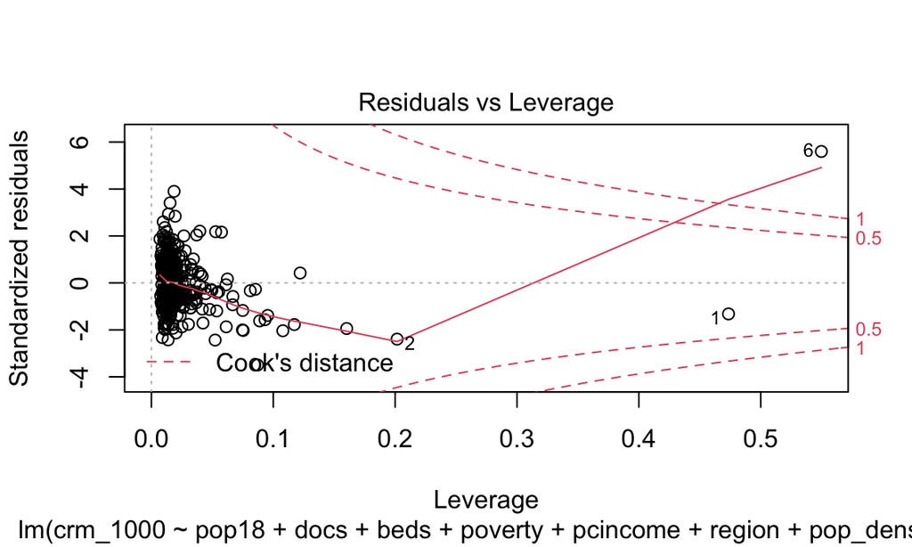

```r
plot(backward, which = 5)
```

```r
crime_df %>%
  filter(row(crime_df) == 6)
```

```
## # A tibble: 1 × 15
##   crm_1000 cty   state pop18 pop65  docs  beds hsgrad bagrad poverty unemp
##      <dbl> <chr> <chr> <dbl> <dbl> <dbl> <dbl>  <dbl>  <dbl>   <dbl> <dbl>
## 1     296. Kings NY     28.3  12.4  4861  8942   63.7   16.6    19.5   9.5
## # … with 4 more variables: pcincome <dbl>, totalinc <dbl>, region <fct>,
## #   pop_density <dbl>
```

```r
backward_df <- crime_df %>%
  filter(row(crime_df) != 6)
```

Excluding the outliers from the analysis

Model 1: doc_totalinc

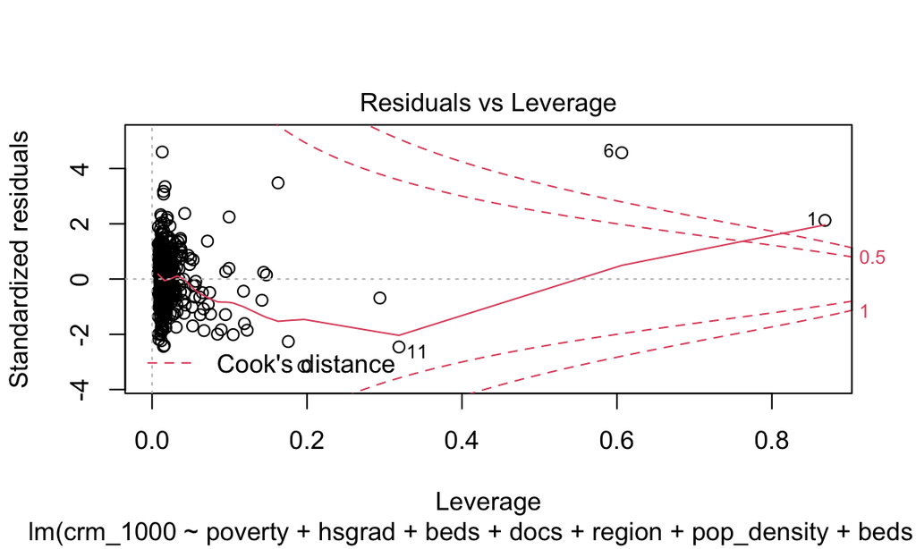

```r
plot(doc_totalinc, which = 5)
```

Excluding the outliers from the analysis, the slope coefficient changes to:

```r
crime_df %>%
  filter(row(crime_df) == 1 | row(crime_df) == 6)
```

```
## # A tibble: 2 × 15
##   crm_1000 cty      state pop18 pop65  docs  beds hsgrad bagrad poverty unemp
##      <dbl> <chr>    <chr> <dbl> <dbl> <dbl> <dbl>  <dbl>  <dbl>   <dbl> <dbl>
## 1     77.7 Los_Ange CA     32.1   9.7 23677 27700   70     22.3    11.6   8
## 2    296.  Kings    NY     28.3  12.4  4861  8942   63.7   16.6    19.5   9.5
## # … with 4 more variables: pcincome <dbl>, totalinc <dbl>, region <fct>,
## #   pop_density <dbl>
```

```r
model_1_df <- crime_df %>%
  filter(row(crime_df) != 1 & row(crime_df) != 6)

new_model_1 = lm(crm_1000 ~ poverty + hsgrad + beds + docs + region + pop_density + beds * docs + beds * totalinc, data = model_1_df)
summary(new_model_1)
```

```
##
## Call:
## lm(formula = crm_1000 ~ poverty + hsgrad + beds + docs + region +
##     pop_density + beds * docs + beds * totalinc, data = model_1_df)
##
## Residuals:
##     Min      1Q  Median      3Q     Max
## -43.364  -9.832  -1.325  10.067  78.452
##
## Coefficients:
##                 Estimate Std. Error t value Pr(>|t|)
## (Intercept)   -1.184e+01  1.491e+01  -0.794  0.42769
## poverty        1.497e+00  2.908e-01   5.148 4.02e-07 ***
## hsgrad         3.850e-01  1.735e-01   2.220  0.02697 *
## beds           9.927e-03  1.416e-03   7.011 9.35e-12 ***
## docs           2.125e-03  3.015e-03   0.705  0.48136
## region2        1.005e+01  2.436e+00   4.125 4.45e-05 ***
## region3        2.677e+01  2.321e+00  11.535  < 2e-16 ***
## region4        1.997e+01  2.811e+00   7.105 5.09e-12 ***
## pop_density    2.107e-03  6.703e-04   3.143  0.00179 **
## totalinc      -6.673e-04  4.095e-04  -1.630  0.10394
## beds:docs     -1.179e-06  5.382e-07  -2.192  0.02895 *
## beds:totalinc  9.210e-08  7.335e-08   1.256  0.20990
## ---
## Signif. codes:  0 '***' 0.001 '**' 0.01 '*' 0.05 '.' 0.1 ' ' 1
##
## Residual standard error: 16.71 on 426 degrees of freedom
## Multiple R-squared:  0.5599, Adjusted R-squared:  0.5485
## F-statistic: 49.27 on 11 and 426 DF,  p-value: < 2.2e-16
```

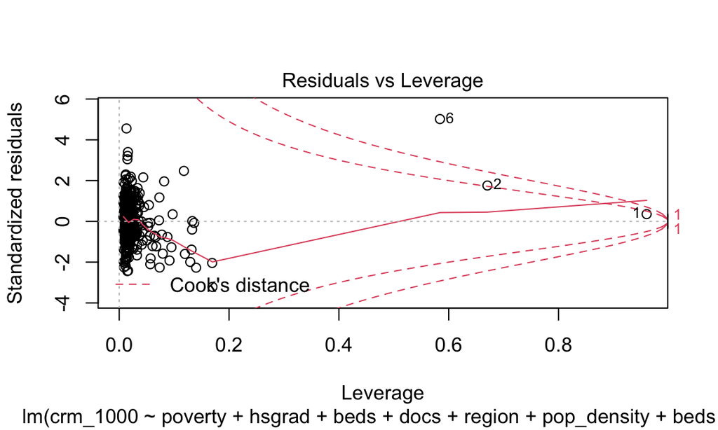

```r
plot(bed_totalinc, which = 5)
```

Excluding the outliers from the analysis, the slope coefficient changes to:

```r
crime_df %>%
  filter(row(crime_df) == 2 | row(crime_df) == 6 | row(crime_df) == 1)
```

```
## # A tibble: 3 × 15
##   crm_1000 cty      state pop18 pop65  docs  beds hsgrad bagrad poverty unemp
##      <dbl> <chr>    <chr> <dbl> <dbl> <dbl> <dbl>  <dbl>  <dbl>   <dbl> <dbl>
## 1     77.7 Los_Ange CA     32.1   9.7 23677 27700   70     22.3    11.6   8
## 2     85.6 Cook     IL     29.2  12.4 15153 21550   73.4   22.8    11.1   7.2
## 3    296.  Kings    NY     28.3  12.4  4861  8942   63.7   16.6    19.5   9.5
## # … with 4 more variables: pcincome <dbl>, totalinc <dbl>, region <fct>,
## #   pop_density <dbl>
```

```r
model_2_df <- crime_df %>%
  filter(row(crime_df) != 2 & row(crime_df) != 6 & row(crime_df) != 1)

new_model_2 = lm(crm_1000 ~ poverty + hsgrad + beds + docs + region + pop_density + beds * docs + beds * totalinc, data = model_2_df)
summary(new_model_2)
```

```
##
## Call:
## lm(formula = crm_1000 ~ poverty + hsgrad + beds + docs + region +
##     pop_density + beds * docs + beds * totalinc, data = model_2_df)
##
## Residuals:
##     Min      1Q  Median      3Q     Max
## -46.637 -10.363  -0.246   9.296  77.363
##
## Coefficients:
##                 Estimate Std. Error t value Pr(>|t|)
## (Intercept)   -9.580e+00  1.444e+01  -0.663   0.5075
## poverty        1.408e+00  2.820e-01   4.993 8.70e-07 ***
## hsgrad         3.102e-01  1.685e-01   1.841   0.0663 .
## beds           1.362e-02  1.530e-03   8.902  < 2e-16 ***
## docs           1.737e-03  2.919e-03   0.595   0.5522
## region2        1.023e+01  2.359e+00   4.338 1.80e-05 ***
## region3        2.737e+01  2.249e+00  12.169  < 2e-16 ***
## region4        2.093e+01  2.727e+00   7.676 1.14e-13 ***
## pop_density    1.628e-03  6.549e-04   2.485   0.0133 *
## totalinc      -2.184e-04  4.049e-04  -0.539   0.5899
## beds:docs     -1.309e-06  5.215e-07  -2.509   0.0125 *
## beds:totalinc -6.402e-08  7.659e-08  -0.836   0.4037
## ---
## Signif. codes:  0 '***' 0.001 '**' 0.01 '*' 0.05 '.' 0.1 ' ' 1
##
## Residual standard error: 16.18 on 425 degrees of freedom
## Multiple R-squared:  0.5872, Adjusted R-squared:  0.5765
## F-statistic: 54.97 on 11 and 425 DF,  p-value: < 2.2e-16
```

## Colinearility

```r
# Correlation matrix for all variables
temp <- crime_df %>%
  dplyr::select(-state, -cty, -region)

cor(temp)
```

```
##                crm_1000       pop18        pop65         docs         beds
## crm_1000     1.00000000  0.19056876 -0.066533283  0.307529058  0.391516689
## pop18        0.19056876  1.00000000 -0.616309639  0.119699240  0.074531907
## pop65       -0.06653328 -0.61630964  1.000000000 -0.003128630  0.053278417
## docs         0.30752906  0.11969924 -0.003128630  1.000000000  0.950464395
## beds         0.39151669  0.07453191  0.053278417  0.950464395  1.000000000
## hsgrad      -0.22641291  0.25058429 -0.268251758 -0.004248085 -0.111916382
## bagrad       0.03830458  0.45609703 -0.339228765  0.236765466  0.100426534
## poverty      0.47184422  0.03397551  0.006578474  0.064136254  0.172793840
## unemp        0.04184658 -0.27852706  0.236309411 -0.050516116  0.007523992
## pcincome    -0.08024417 -0.03164843  0.018590706  0.316134625  0.194808180
## totalinc     0.22815575  0.07116151 -0.022733151  0.948110571  0.902061545
## pop_density  0.48042848  0.12546440  0.029184452  0.406438634  0.428839199
##                   hsgrad      bagrad      poverty        unemp    pcincome
## crm_1000    -0.226412914  0.03830458  0.471844218  0.041846579 -0.08024417
## pop18        0.250584290  0.45609703  0.033975512 -0.278527058 -0.03164843
## pop65       -0.268251758 -0.33922877  0.006578474  0.236309411  0.01859071
## docs        -0.004248085  0.23676547  0.064136254 -0.050516116  0.31613462
## beds        -0.111916382  0.10042653  0.172793840  0.007523992  0.19480818
## hsgrad       1.000000000  0.70778672 -0.691750483 -0.593595788  0.52299613
## bagrad       0.707786723  1.00000000 -0.408423848 -0.540906913  0.69536186
## poverty     -0.691750483 -0.40842385  1.000000000  0.436947236 -0.60172504
## unemp       -0.593595788 -0.54090691  0.436947236  1.000000000 -0.32214439
## pcincome     0.522996133  0.69536186 -0.601725039 -0.322144395  1.00000000
## totalinc     0.043355729  0.22223013 -0.038739339 -0.033876330  0.34768161
## pop_density -0.104007024  0.15560626  0.126507888  0.022717901  0.23322601
##                totalinc pop_density
## crm_1000     0.22815575  0.48042848
## pop18        0.07116151  0.12546440
## pop65       -0.02273315  0.02918445
## docs         0.94811057  0.40643863
## beds         0.90206155  0.42883920
## hsgrad       0.04335573 -0.10400702
## bagrad       0.22223013  0.15560626
## poverty     -0.03873934  0.12650789
## unemp       -0.03387633  0.02271790
## pcincome     0.34768161  0.23322601
## totalinc     1.00000000  0.31620475
## pop_density  0.31620475  1.00000000
```

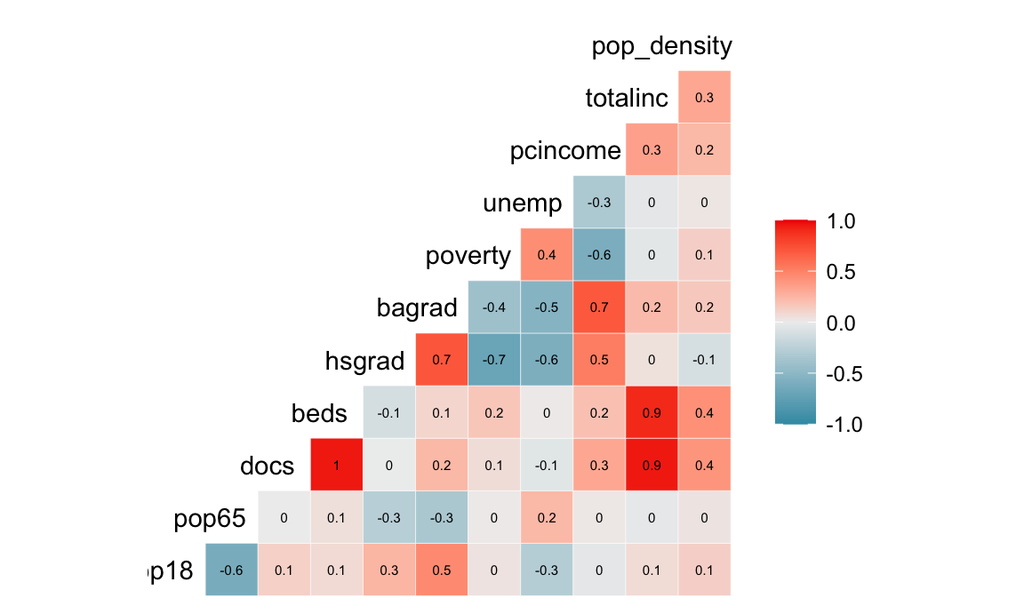

```r
crime_df %>%
  dplyr::select(-crm_1000) %>%
  ggcorr(label = TRUE, label_size = 2, hjust = 0.8)
```

The correlation plot suggest high correlation between beds and docs, beds and totalinc, docs and totalinc.

Let’s check if the model violates colienarity

```r
check_collinearity(bed_totalinc)
```

```
## # Check for Multicollinearity
##
## Low Correlation
##
##           Term  VIF Increased SE Tolerance
##        poverty 2.45         1.57      0.41
##         hsgrad 2.14         1.46      0.47
##           beds 1.30         1.14      0.77
##           docs 1.11         1.05      0.90
##         region 1.41         1.19      0.71
##    pop_density 1.00         1.00      1.00
##       totalinc 1.01         1.00      0.99
##      beds:docs 1.00         1.00      1.00
##  docs:totalinc 1.00         1.00      1.00
```

```r
check_collinearity(doc_totalinc)
```

```
## # Check for Multicollinearity
##
## Low Correlation
##
##           Term  VIF Increased SE Tolerance
##        poverty 2.45         1.57      0.41
##         hsgrad 2.20         1.48      0.45
##           beds 1.20         1.10      0.83
##           docs 1.29         1.14      0.77
##         region 1.42         1.19      0.70
##    pop_density 1.00         1.00      1.00
##       totalinc 1.01         1.01      0.99
##      beds:docs 1.00         1.00      1.00
##  beds:totalinc 1.00         1.00      1.00
```

```r
check_collinearity(backward)
```

```
## # Check for Multicollinearity
##
## Low Correlation
##
##         Term  VIF Increased SE Tolerance
##        pop18 1.13         1.06      0.88
##         docs 1.40         1.18      0.71
##         beds 1.30         1.14      0.77
##      poverty 1.17         1.08      0.85
##     pcincome 1.06         1.03      0.94
##       region 1.33         1.15      0.75
##  pop_density 1.02         1.01      0.98
```

## Final models

```r
backward = lm(crm_1000 ~ cty + state + pop65 + docs + beds + hsgrad + bagrad +
    poverty + pcincome + totalinc + pop_density, data = backward_df)

doc_totalinc = lm(crm_1000 ~ poverty + hsgrad + beds + docs + region + pop_density + beds * docs + beds * totalinc, data = model_1_df)

bed_totalinc = lm(crm_1000 ~ poverty + hsgrad + beds + docs + region + pop_density + beds * docs + docs * totalinc, data = model_2_df)

backward %>% broom::tidy()
```

```
## # A tibble: 427 × 5
##    term        estimate std.error statistic p.value
##    <chr>          <dbl>     <dbl>     <dbl>   <dbl>
##  1 (Intercept)  -166.        84.0    -1.98   0.0581
##  2 ctyAdams        7.79      28.0     0.279  0.783
##  3 ctyAiken      -11.8       27.3    -0.433  0.668
##  4 ctyAlachua     33.2       30.8     1.08   0.291
##  5 ctyAlamance   -17.0       32.1    -0.530  0.600
##  6 ctyAlameda     15.8       34.5     0.456  0.652
##  7 ctyAlbany      17.5       25.8     0.679  0.503
##  8 ctyAlexandr    -8.48      33.1    -0.256  0.800
##  9 ctyAlleghen   -27.9       26.8    -1.04   0.306
## 10 ctyAllen        9.91      20.2     0.492  0.627
## # … with 417 more rows
```

```r
doc_totalinc %>% broom::tidy()
```

```
## # A tibble: 12 × 5
##    term          estimate     std.error statistic  p.value
##    <chr>            <dbl>         <dbl>     <dbl>    <dbl>
##  1 (Intercept)   -1.18e+1 14.9             -0.794 4.28e- 1
##  2 poverty        1.50e+0  0.291            5.15  4.02e- 7
##  3 hsgrad         3.85e-1  0.173            2.22  2.70e- 2
##  4 beds           9.93e-3  0.00142          7.01  9.35e-12
##  5 docs           2.12e-3  0.00301          0.705 4.81e- 1
##  6 region2        1.01e+1  2.44             4.13  4.45e- 5
##  7 region3        2.68e+1  2.32            11.5   5.63e-27
##  8 region4        2.00e+1  2.81             7.11  5.09e-12
##  9 pop_density    2.11e-3  0.000670         3.14  1.79e- 3
## 10 totalinc      -6.67e-4  0.000409        -1.63  1.04e- 1
## 11 beds:docs     -1.18e-6  0.000000538     -2.19  2.90e- 2
## 12 beds:totalinc  9.21e-8  0.0000000733     1.26  2.10e- 1
```

```r
bed_totalinc %>% broom::tidy()
```

```
## # A tibble: 12 × 5
##    term              estimate     std.error statistic  p.value
##    <chr>                <dbl>         <dbl>     <dbl>    <dbl>
##  1 (Intercept)   -8.24        14.3             -0.577 5.64e- 1
##  2 poverty        1.44         0.283            5.10  5.20e- 7
##  3 hsgrad         0.288        0.168            1.72  8.61e- 2
##  4 beds           0.0116       0.00209          5.57  4.57e- 8
##  5 docs           0.00412      0.00231          1.78  7.50e- 2
##  6 region2       10.4          2.36             4.42  1.25e- 5
##  7 region3       27.3          2.24            12.2   1.60e-29
##  8 region4       20.7          2.73             7.60  1.91e-13
##  9 pop_density    0.00152      0.000654         2.33  2.04e- 2
## 10 totalinc      -0.0000820    0.000382        -0.215 8.30e- 1
## 11 beds:docs     -0.00000122   0.000000418     -2.92  3.71e- 3
## 12 docs:totalinc -0.000000120  0.0000000875    -1.37  1.71e- 1
```

There is no colinearity in our models